# Cantonese

This is final permutation and mixed model analysis for Chan, Yang, Chang, & Kidd (in press)

```r
knitr::opts_chunk$set(warning = FALSE)
knitr::knit_theme$set("zmrok")

## The following loads ggplot2 and stringr
require(tidyverse)
require(stringr)
require(lme4)
require(nlme)      ## for lme()
require(lsmeans)   ## for lsmeans()
require(multcomp)  ## for multiple comparison stuff
require(remef)
print(R.version.string)
```

```
## [1] "R version 4.1.0 (2021-05-18)"
```

```r
apaformat <- function(p){
    # make the theme black-and-white
    # rather than grey
    # (do this before font changes, or it overrides them)
    p = p + theme_bw()
    p = p + theme(
          # switch off major gridlines
          panel.grid.major = element_blank(),

          # switch off minor gridlines
          panel.grid.minor = element_blank(),

          # switch off the rectangle around symbols in the legend
          legend.key = element_blank()
    )
    return(p)
}
```

In the following code chunks, the combination of `tidyverse` functions and pipe (`|>`), rather than base functions, are applied. Such ‘tidy’ methods will enhance the readability of the codes and speed of the code evaluation. Moreover, the tidy methods enable you to save memory, since you do not have to create intermediate objects.

Although the application of the tidy methods may change the row order in a data frame, the row values are identical. You can check this by runnning:

```
dplyr::all_equal(
  data.frame.created.by.base.function,
  corresponding.data.frame.created.by.tidy.methods,
  ignore_col_order = FALSE,
  ignore_row_order = FALSE,
  convert = TRUE
  )
```

```r
# Create a data frame with onset-offset data for each condition in study
onsetStimCL = data.frame(
  SentenceType = c(
    rep("Subject", 3),
    rep("Object", 4)
    ),
  cat = c(
    "VN", "D CL", "Head",
    "N", "V", "D CL", "Head"
    ),
  onset = c(
    0, 0.625, 0.91,
    0, 0.412, 0.661, 0.925
    ),
  HeadNoun = rep("CL", 7)
  )

onsetStimGE = data.frame(
  SentenceType = c(
    rep("Subject", 3),
    rep("Object", 4)
    ),
  cat = c(
    "VN", "ge", "Head",
    "N", "V", "ge", "Head"
    ),
  onset = c(
    0, 0.741, 0.899,
    0, 0.488, 0.756, 0.939
    ),
  HeadNoun = rep("ge3", 7)
  )

onsetStim = bind_rows(
  onsetStimCL,
  onsetStimGE
  ) |>
  mutate(
    time = onset * 1000,
    time2 = c(
      622, 907, 1497, 409,
      658, 922, 1387, 738,
      896, 1454, 485, 753,
      936, 1477
      ),
    ypos = rep(
      c(rep(0.95, 3), rep(0.75, 4)),
      2
      ),
    target = 1,
    restarg = 0
  )


##  mutate(
##    time = onset * 1000,
##    time2 = case_when(
##        cat == "Head" & SentenceType == "Subject" & HeadNoun == "CL"
##          ~ 1.477*1000,
##        cat == "Head" & SentenceType == "Object"  & HeadNoun == "CL"
##          ~ 1.387*1000,
##        cat == "Head" & SentenceType == "Subject" & HeadNoun == "ge3"
##          ~ 1.454*1000,
##        cat == "Head" & SentenceType == "Object"  & HeadNoun == "ge3"
##          ~ 1.477*1000,
##        TRUE ~ lag(
##          time, 0
##          )
##        )
##    )

onsetStim |>
  filter(cat == "Head")
```

```
##   SentenceType  cat onset HeadNoun time time2 ypos target restarg
## 1      Subject Head 0.910       CL  910  1497 0.95      1       0
## 2       Object Head 0.925       CL  925  1387 0.75      1       0
## 3      Subject Head 0.899      ge3  899  1454 0.95      1       0
## 4       Object Head 0.939      ge3  939  1477 0.75      1       0
```

```r
onsetStim |>
  group_by(
    HeadNoun, cat
  ) |>
  summarise(
    time2 = mean(time2)
  )
```

```
## # A tibble: 10 x 3
## # Groups:   HeadNoun [2]
##    HeadNoun cat   time2
##    <chr>    <chr> <dbl>
##  1 CL       D CL   914.
##  2 CL       Head  1442
##  3 CL       N      409
##  4 CL       V      658
##  5 CL       VN     622
##  6 ge3      ge     916
##  7 ge3      Head  1466.
##  8 ge3      N      485
##  9 ge3      V      753
## 10 ge3      VN     738
```

```r
# load eye-tracking data
# with `reader::read_csv` (from tidyverse)
#
# `reader::read_csv` interprets the data with
# greater acurracy than `base::read.csv` and
# `reader::read_csv` prunes the following line:
# bothdata$time = as.numeric(as.character(bothdata$time))
bothdata = read_csv("CanRCeyetracking data-19 for CL &18 for GE-only TTR longer than 200ms.csv")  |>
  mutate(
    HeadNoun = factor(
      HeadNoun,
      labels = c("CL", "ge3")
      ),
    SentenceType = factor(
      SentenceType,
      labels = c("Subject", "Object"),
      levels = c("subject", "object")
      ),
    Item = str_replace(
      Item,
      "(S|O)",
      "I"
      ),
  time = time * 1000,
  target = `T`
  )
xtabs(~ Item + HeadNoun, bothdata)
```

```
##     HeadNoun
## Item   CL  ge3
##   I1 1998    0
##   I2 1924    0
##   I3 1628    0
##   I4 2220    0
##   I5    0 1554
##   I6    0 1850
##   I7    0 1628
##   I8    0 1702
```

```r
xtabs(~ Item + SentenceType, bothdata)
```

```
##     SentenceType
## Item Subject Object
##   I1     962   1036
##   I2     962    962
##   I3     814    814
##   I4    1036   1184
##   I5     888    666
##   I6     888    962
##   I7     962    666
##   I8     962    740
```

1. Group `bothdata` by the columns `time`, `HeadNoun`, and `SentenceType` using `dplyr::group_by()`
2. Calculate the mean proportion of gaze to `target` by the group created using `dplyr::group_by(time, HeadNoun, SentenceType)`
3. Plot the mean proportion of gaze to `target` using `ggplot2::ggplot()`

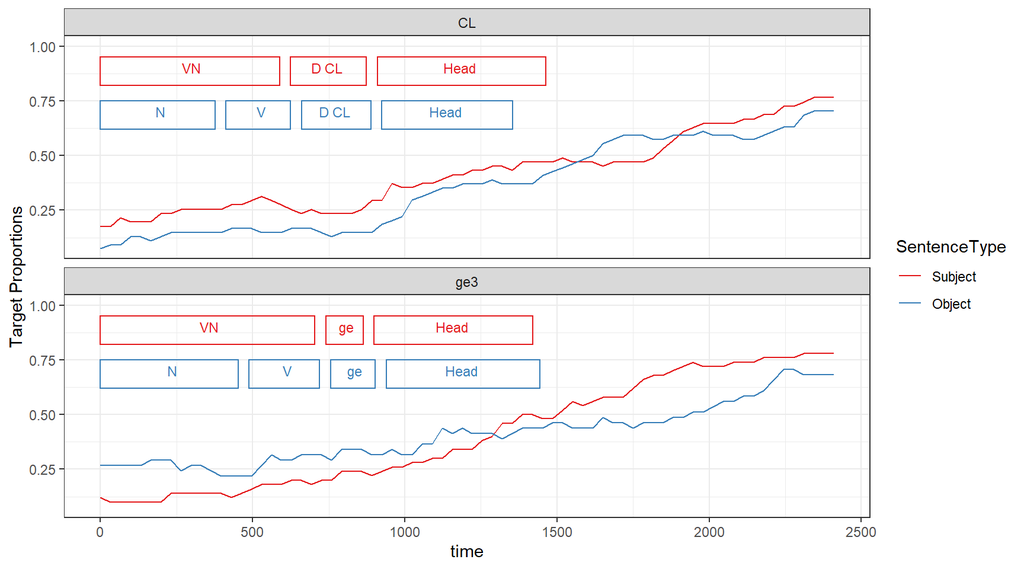

```r
# Figure to see raw data
bothdata |>
  group_by(time, HeadNoun, SentenceType) |>
  summarise(target = mean(target)) |>
  ggplot(
    aes(
      x = time,
      y = target,
      colour=SentenceType
      )
    ) +
  geom_line() +
  scale_colour_brewer(palette="Set1") +
  # change background to white
  theme_bw() +
  ylab("Target Proportions") +
  #ylim(0,1) +
  facet_wrap(~ HeadNoun, ncol=1) +
  geom_rect(
    data = onsetStim,
    aes(
      xmin = time,
      xmax = time2-33,
      ymin = ypos-0.13,
      ymax = ypos,
      colour = SentenceType
      ),
    fill = NA,
    show.legend = FALSE
    ) +
  geom_text(
    data = onsetStim,
    aes(
      x = (time+time2)/2,
      y = ypos-0.05,
      label = cat
      ),
    hjust = 0.7,
    size = 3,
    show.legend = FALSE
  )
```

Above is the raw data, below we remove the mean of time 0.

1. Assign the following data to the object named `both`
2. From `bothdata`, `filter` out the data whose `time` is 0
3. Group that data by the columns `Participant`, `Item`, `HeadNoun`, and `SentenceType` using `dplyr::group_by()`
4. Calculate the mean proportion of gaze to `target` by the group created using `dplyr::group_by(Participant, Item, HeadNoun, SentenceType)`
5. `Join` that filtered data to the original `bothdata` by the columns `Participant`, `Item`, `HeadNoun`, and `SentenceType`; at the same time, attach `suffix`es to the duplicate columns (especially the column `target`), so that you can identify which data frame the duplicate columns originally came from.
6. `Mutate` the joined data, so that its `target` indicates the subtraction of `target.filtered` from `target.original`

```r
both <- bothdata |>
  filter(time == 0) |>
  group_by(Participant, Item, HeadNoun, SentenceType) |>
  summarise(target = mean(target)) |>
  right_join(
    # filtered `bothdata` is the first data frame to be combined
    #`bothdata` is the second data frame to be combined
    bothdata,
    by = c(
      "Participant",
      "Item",
      "HeadNoun",
      "SentenceType"
      ),
    # Suffixes must be in this order,
    # since filtered `bothdata` is the first data frame and
    # original `bothdata` is the second:
    suffix = c(".filtered", ".original")
  ) |>
  mutate(
    target = target.original - target.filtered
  )
```

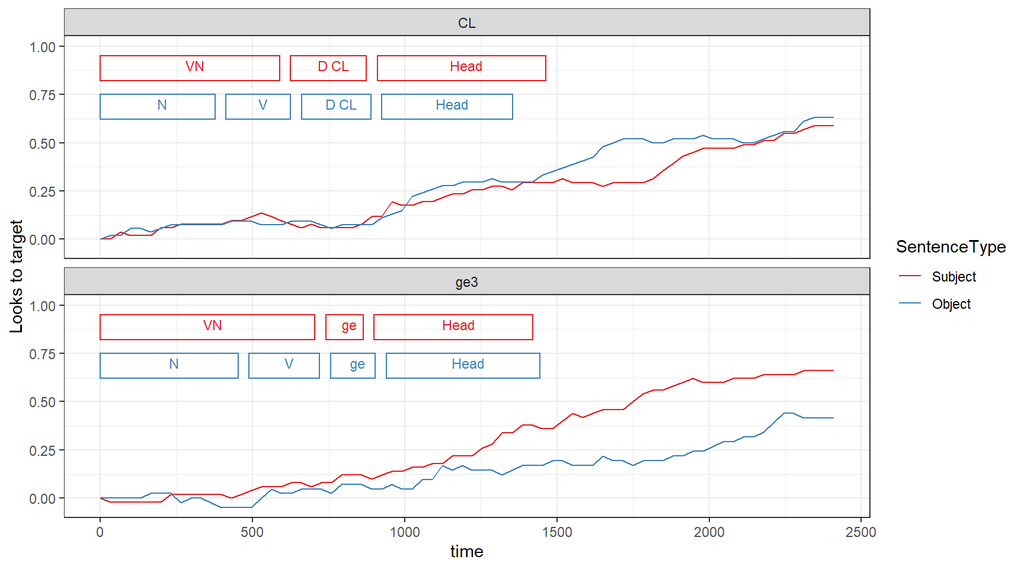

```r
# plot figure for dataset
both |>
  group_by(
    time, HeadNoun, SentenceType
  ) |>
  summarise(
    target = mean(target)
  ) |>
  ggplot(
    aes(
      x = time,
      y = target,
      colour = SentenceType
      )
    ) +
  geom_line() +
  scale_colour_brewer(palette = "Set1") +
  # change background to white
  theme_bw() +
  ylab("Looks to target") +
  #ylim(0,1) +
  facet_wrap(~ HeadNoun, ncol = 1) +
  geom_rect(
    data = onsetStim,
    aes(
      xmin = time,
      xmax = time2 - 33,
      ymin = ypos - 0.13,
      ymax = ypos,
      colour = SentenceType
      ),
    fill = NA,
    show.legend = FALSE
    ) +
    geom_text(
      data = onsetStim,
      aes(
        x = (time + time2)/2,
        y = ypos - 0.05,
        label = cat),
        size = 3,
        show.legend = FALSE
    )
```

Here is a mixed model analysis using 200 ms windows

```r
winsize = 200

#unique(both$time)
both$win = as.integer((both$time+10)/winsize)
xtabs(~ win, both)
```

```
## win
##    0    1    2    3    4    5    6    7    8    9   10   11   12
## 1176 1176 1176 1176 1176 1372 1176 1176 1176 1176 1176 1176  196
```

```r
both2 = subset(both, win != 12 & !is.na(time)) # not enough data in 12
xtabs(~ win, both2)
```

```
## win
##    0    1    2    3    4    5    6    7    8    9   10   11
## 1176 1176 1176 1176 1176 1372 1176 1176 1176 1176 1176 1176
```

```r
xtabs(~ Item + HeadNoun, both)
```

```
##     HeadNoun
## Item   CL  ge3
##   I1 1998    0
##   I2 1924    0
##   I3 1628    0
##   I4 2220    0
##   I5    0 1554
##   I6    0 1850
##   I7    0 1628
##   I8    0 1702
```

```r
xtabs(~ Participant + SentenceType, both)
```

```
##            SentenceType
## Participant Subject Object
##          1      148    222
##          2      296    296
##          3      148     74
##          4      148    222
##          5      148    222
##          6      148    222
##          7      296    296
##          8      222    222
##          9      148    296
##          10     222    222
##          11      74    222
##          12     222      0
##          13     296    296
```

[output cut: 24 more lines]

```r
subjmeans.df = aggregate(target ~ win + HeadNoun + SentenceType + Participant + Item, both, mean)
subjmeans.df$time=subjmeans.df$win*winsize
subjmeans.df$cwin = subjmeans.df$win - mean(subjmeans.df$win)
subjmeans.df$cCL = ifelse(subjmeans.df$HeadNoun == "CL",0.5,-0.5)
subjmeans.df$cobject = ifelse(subjmeans.df$SentenceType == "Object",0.5,-0.5)
subjmeans.df$Participant=factor(subjmeans.df$Participant)
subjmeans.df$Item=factor(subjmeans.df$Item)
mixmodel = lmer(target ~ cwin*cCL*cobject + (1 + SentenceType| Participant) + (1+SentenceType | Item), subjmeans.df)
summixed=summary(mixmodel)
print(summixed)
```

```
## Linear mixed model fit by REML ['lmerMod']
## Formula: target ~ cwin * cCL * cobject + (1 + SentenceType | Participant) +
##     (1 + SentenceType | Item)
##    Data: subjmeans.df
##
## REML criterion at convergence: 3441.5
##
## Scaled residuals:
##     Min      1Q  Median      3Q     Max
## -3.1647 -0.6247 -0.0445  0.7211  2.7589
##
## Random effects:
##  Groups      Name               Variance Std.Dev. Corr
##  Participant (Intercept)        0.04044  0.2011
##              SentenceTypeObject 0.09552  0.3091   -0.64
##  Item        (Intercept)        0.01290  0.1136
##              SentenceTypeObject 0.02001  0.1414   -0.73
##  Residual                       0.20729  0.4553
## Number of obs: 2548, groups:  Participant, 37; Item, 8
##
## Fixed effects:
##                   Estimate Std. Error t value
## (Intercept)       0.250847   0.039928   6.282
## cwin              0.051817   0.002424  21.380
## cCL               0.062635   0.079856   0.784
## cobject          -0.024686   0.075504  -0.327
## cwin:cCL          0.000416   0.004847   0.086
## cwin:cobject     -0.011028   0.004847  -2.275
## cCL:cobject       0.186426   0.151007   1.235
## cwin:cCL:cobject  0.036199   0.009694   3.734
##
## Correlation of Fixed Effects:
##             (Intr) cwin   cCL    cobjct cwn:CL cwn:cb cCL:cb
## cwin         0.000
## cCL         -0.038  0.000
## cobject      0.036  0.000 -0.020
## cwin:cCL     0.000 -0.076  0.000  0.000
## cwin:cobjct  0.000  0.040  0.000  0.000 -0.066
## cCL:cobject -0.020  0.000  0.036 -0.042  0.000  0.000
## cwn:cCL:cbj  0.000 -0.066  0.000  0.000  0.040 -0.076  0.000
```

```r
clwin8 = subset(subjmeans.df, win==8 & HeadNoun == "CL")
mixmodel8cl = lmer(target ~ cobject + (1+SentenceType | Participant) + (1+SentenceType | Item), clwin8)
```

```
## boundary (singular) fit: see ?isSingular
```

```r
print(summary(mixmodel8cl))
```

```
## Linear mixed model fit by REML ['lmerMod']
## Formula:
## target ~ cobject + (1 + SentenceType | Participant) + (1 + SentenceType |
##     Item)
##    Data: clwin8
##
## REML criterion at convergence: 181.8
##
## Scaled residuals:
##     Min      1Q  Median      3Q     Max
## -2.5964 -0.6975 -0.2576  0.8984  1.5195
##
## Random effects:
##  Groups      Name               Variance  Std.Dev. Corr
##  Participant (Intercept)        0.0245185 0.15658
##              SentenceTypeObject 0.0001949 0.01396  1.00
##  Item        (Intercept)        0.0180736 0.13444
##              SentenceTypeObject 0.0429861 0.20733  -1.00
##  Residual                       0.2890259 0.53761
## Number of obs: 105, groups:  Participant, 19; Item, 4
##
## Fixed effects:
##             Estimate Std. Error t value
## (Intercept)  0.39367    0.06685   5.889
## cobject      0.20928    0.14883   1.406
##
## Correlation of Fixed Effects:
##         (Intr)
## cobject -0.158
## optimizer (nloptwrap) convergence code: 0 (OK)
## boundary (singular) fit: see ?isSingular
```

```r
ge3win9 = subset(subjmeans.df, win==9 & HeadNoun == "ge3")
ge3win10 = subset(subjmeans.df, win==10 & HeadNoun == "ge3")
ge3win9$target2 = ge3win10$target
print(cor(ge3win9$target,ge3win9$target2))
```

```
## [1] 0.9433795
```

Since we have a significant three way interaction of HeadNoun, SentenceType, and window, we can do posthocs. We use lsmeans to do contrasts between obj and sub for each window in each HeadNoun. lsmeans also adjusts p automatically for the number of comparisons.

```r
options(contrasts = c("contr.treatment", "contr.poly"))
subjmeans.df$win = factor(subjmeans.df$win)
subjmeans.df$HeadNoun = factor(subjmeans.df$HeadNoun)
subjmeans.df$SentenceType = factor(subjmeans.df$SentenceType)
mixmodelFactor = lmer(target ~ win*SentenceType*HeadNoun + (1 + SentenceType| Participant) + (1+SentenceType | Item), subjmeans.df)
model.lsmobj <- lsmeans(mixmodelFactor, ~ SentenceType | win*HeadNoun)
posthocs = summary(as.glht(pairs(model.lsmobj)))
```

```
## Note: df set to 55
```

```r
print(posthocs)
```

```
## $`win = 0, HeadNoun = CL`
##
##   Simultaneous Tests for General Linear Hypotheses
##
## Linear Hypotheses:
##                       Estimate Std. Error t value Pr(>|t|)
## Subject - Object == 0 -0.04221    0.13521  -0.312    0.756
## (Adjusted p values reported -- single-step method)
##
##
## $`win = 1, HeadNoun = CL`
##
##   Simultaneous Tests for General Linear Hypotheses
##
## Linear Hypotheses:
##                       Estimate Std. Error t value Pr(>|t|)
## Subject - Object == 0 -0.02678    0.13521  -0.198    0.844
## (Adjusted p values reported -- single-step method)
##
##
## $`win = 2, HeadNoun = CL`
##
##   Simultaneous Tests for General Linear Hypotheses
##
## Linear Hypotheses:
##                        Estimate Std. Error t value Pr(>|t|)
## Subject - Object == 0 -0.003175   0.135205  -0.023    0.981
## (Adjusted p values reported -- single-step method)
##
##
## $`win = 3, HeadNoun = CL`
##
##   Simultaneous Tests for General Linear Hypotheses
##
## Linear Hypotheses:
##                       Estimate Std. Error t value Pr(>|t|)
## Subject - Object == 0 -0.03604    0.13521  -0.267    0.791
## (Adjusted p values reported -- single-step method)
##
##
```

[output cut: 211 more lines]

```
##
## Linear Hypotheses:
##                       Estimate Std. Error t value Pr(>|t|)
## Subject - Object == 0   0.1936     0.1432   1.352    0.182
## (Adjusted p values reported -- single-step method)
##
##
## $`win = 12, HeadNoun = ge3`
##
##   Simultaneous Tests for General Linear Hypotheses
##
## Linear Hypotheses:
##                       Estimate Std. Error t value Pr(>|t|)
## Subject - Object == 0   0.2077     0.1432    1.45    0.153
## (Adjusted p values reported -- single-step method)
```

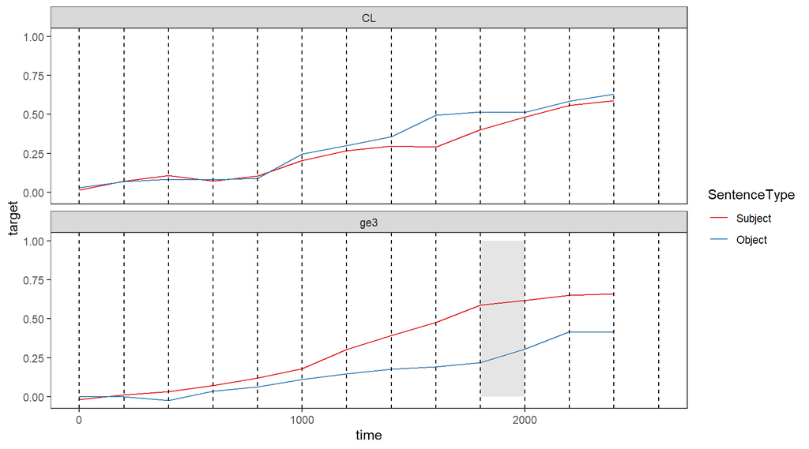

```r
subjmeans.df$pred <- remef(mixmodelFactor, ran = "all")
means2.df = aggregate(cbind(pred,target) ~ time + HeadNoun + SentenceType, subjmeans.df, mean)
timelist = as.integer(unique(subjmeans.df$time))
p = ggplot(means2.df , aes( x = time, y = target, colour=SentenceType))
meanwin= data.frame(time= rep(timelist,2),HeadNoun=rep(c("CL","ge3"),each=length(timelist)))
meanwin$pval = as.numeric(lapply(posthocs, function(x){ return( x$test$pvalues[1]) }) )
meanwin$target = 0
meanwin$pred =0
meanwin$SentenceType = "Object"
meansigPost = subset(meanwin,pval < 0.05)
# color them grey
p = p + geom_rect(data=meansigPost,aes(xmin=time, xmax=time+winsize, ymin = 0, ymax= 1.0),,colour=NA,fill="grey90",show.legend=FALSE)
p = p + geom_line()
p = p + facet_wrap(~ HeadNoun, ncol=1)
p = p + scale_colour_brewer(palette="Set1")
p = p + scale_fill_brewer(palette="Set2")
p = p + geom_vline(xintercept = seq(0,2600,by=winsize),colour="black", linetype = 2)
apaformat(p)
```

This is the permutation analysis

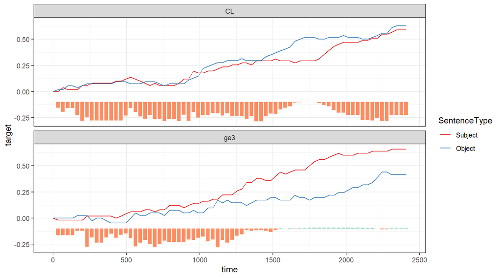

```r
# create copy of data frame
pdata = both[!is.na(both$time),]
wdivsize = 1
pdata$cobject = ifelse(pdata$SentenceType == "Subject",0.5,-0.5)
pdata$win = as.integer(pdata$time/wdivsize)
pdata$time = pdata$win*wdivsize

# create data frame which averages over subjects.
# This also stores the results of the permutation analysis
means.df = aggregate(target ~ SentenceType + cobject + time + HeadNoun, pdata, mean)
means.df$pstr = 1000

# We do this for each timebin in the data
timelist = unique(pdata$time)
for (l in c("CL","ge3")){
  for (t in timelist){
    # create data frame for ONE timebin for each HeadNoun level
    onetime = subset(pdata,time == t & HeadNoun == l)
    # do regression model on target using structure SentenceTypeition
    onemodel = lm(target ~ cobject, onetime)
    # print(summary(tarmodel))
    # this is the t-value for structure
    targetT = coef(summary(onemodel))[2,3]  # observed t-value
    targetP = abs(coef(summary(onemodel))[2,4])  # observed p-value
    means.df$tstr[means.df$time == t & means.df$HeadNoun == l] = targetT
    means.df$pstr[means.df$time == t & means.df$HeadNoun == l] = targetP
  }
}

# to see these p-values, we draw them arbitrarily on the graph at 0.2.
# when the p-value < 0.05, we draw a blue line above 0.2
# when the p-value > 0.05, we draw an orange line below 0.2
pliney = -0.1
plinemax = 0.2
means.df$pline = pliney+plinemax*(0.05-means.df$pstr)
means.df$plinecol = ifelse(means.df$pstr < 0.05,"a","b")
wsize = mean(pdata$time[2:5] - pdata$time[1:4] - 8)/2
means.df$SentenceType=factor(means.df$SentenceType,levels=c("Subject","Object"))
p = ggplot(means.df , aes( x = time, y = target, colour=SentenceType))
p = p + geom_line()
p = p + scale_colour_brewer(palette="Set1")
p = p + scale_fill_brewer(palette="Set2")
p = p + theme_bw()   # change background to white
p = p + facet_wrap(~ HeadNoun, ncol=1)
p = p + geom_rect(aes(xmin=time-wsize, xmax=time+wsize, ymin = pliney, ymax= pline, fill=plinecol),colour=NA,show.legend=FALSE)
p
```

```r
# Also, each window is not independent, so we create clusters for adjacent windows with p<0.05
# cnum is the cluster number and we increment the number when the p value is > 0.05
# so clusters with the same cnum are part of the same cluster
cnum = 1
lastpval = 100
lasttdir = 1
means.df$cnum = 1
for (l in c("CL","ge3")){
  for (t in timelist[2:length(timelist)]){
    onetime = subset(means.df,time == t & HeadNoun == l & SentenceType == "Object")
    pval = abs(onetime$pstr)
    tdir = onetime$tstr
    if (pval < 0.05 & lastpval > 0.05 ){
      cnum = cnum + 1  # increase cluster number when entering a significant cluster from a non-significant cluster
    }
    if (pval > 0.05 ){
      cnum = cnum + 1 # increase cluster number when not significant
    }else{
      # if t value flips direction, even if both are signif,
      # we should treat those as separate clusters
      if (lasttdir*tdir < 0){
        cnum = cnum + 1
      }
    }
    lastpval = pval
    lasttdir = tdir
    means.df$cnum[means.df$time == t & means.df$HeadNoun == l] = cnum
  }
  cnum=cnum+1  # new cluster for different HeadNounuages
}
head(means.df,10)
```

```
##    SentenceType cobject time HeadNoun     target      pstr       tstr
## 1        Object    -0.5    0       CL 0.00000000       NaN        NaN
## 2       Subject     0.5    0       CL 0.00000000       NaN        NaN
## 3        Object    -0.5   33       CL 0.01851852 0.3335439 -0.9715633
## 4       Subject     0.5   33       CL 0.00000000 0.3335439 -0.9715633
## 5        Object    -0.5   66       CL 0.01851852 0.5291920  0.6313782
## 6       Subject     0.5   66       CL 0.03921569 0.5291920  0.6313782
## 7        Object    -0.5   99       CL 0.05555556 0.3409293 -0.9567588
## 8       Subject     0.5   99       CL 0.01960784 0.3409293 -0.9567588
## 9        Object    -0.5  132       CL 0.05555556 0.3409293 -0.9567588
## 10      Subject     0.5  132       CL 0.01960784 0.3409293 -0.9567588
##         pline plinecol cnum
## 1         NaN     <NA>    1
## 2         NaN     <NA>    1
## 3  -0.1567088        b    2
## 4  -0.1567088        b    2
## 5  -0.1958384        b    3
## 6  -0.1958384        b    3
## 7  -0.1581859        b    4
## 8  -0.1581859        b    4
## 9  -0.1581859        b    5
## 10 -0.1581859        b    5
```

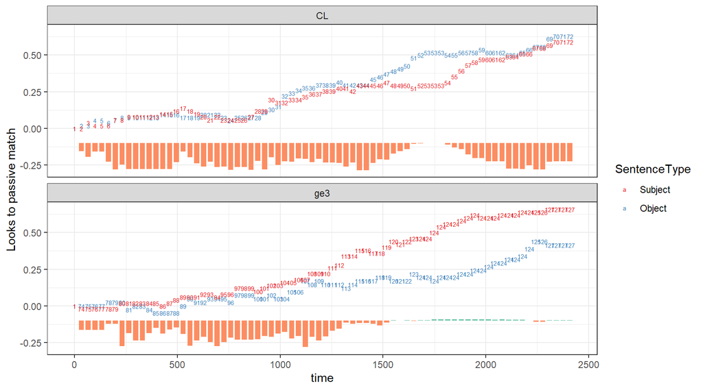

```r
# this shows the clusters
p = ggplot(means.df , aes( x = time, y = target, colour=SentenceType, label=cnum))
p = p + scale_colour_brewer(palette="Set1")
p = p + scale_fill_brewer(palette="Set2")
p = p + theme_bw()   # change background to white
p = p + ylab("Looks to passive match")
#p = p + ylim(0,1)
p = p + facet_wrap(~ HeadNoun, ncol=1)
p = p + geom_rect(aes(xmin=time-wsize, xmax=time+wsize, ymin = pliney, ymax= pline, fill=plinecol),colour=NA,show.legend=FALSE)
p + geom_text(size=2)
```

```r
# we now want to identify the clusters that were significant
# p-values are same for subject/object, so just use object.
meansonlyact.df = subset(means.df, SentenceType == "Object")
sigcluster = subset(meansonlyact.df, abs(pstr) < 0.05 )
print(sigcluster,digits=3)
```

```
##     SentenceType cobject time HeadNoun target    pstr  tstr   pline plinecol
## 105       Object    -0.5 1716       CL  0.519 0.04833 -2.00 -0.0997        a
## 107       Object    -0.5 1749       CL  0.519 0.04833 -2.00 -0.0997        a
## 109       Object    -0.5 1782       CL  0.519 0.04833 -2.00 -0.0997        a
## 243       Object    -0.5 1551      ge3  0.171 0.03617  2.13 -0.0972        a
## 247       Object    -0.5 1617      ge3  0.171 0.03617  2.13 -0.0972        a
## 251       Object    -0.5 1683      ge3  0.195 0.04144  2.07 -0.0983        a
## 253       Object    -0.5 1716      ge3  0.195 0.04144  2.07 -0.0983        a
## 255       Object    -0.5 1749      ge3  0.171 0.01109  2.59 -0.0922        a
## 257       Object    -0.5 1782      ge3  0.195 0.00844  2.69 -0.0917        a
## 259       Object    -0.5 1815      ge3  0.195 0.00536  2.85 -0.0911        a
## 261       Object    -0.5 1848      ge3  0.195 0.00536  2.85 -0.0911        a
## 263       Object    -0.5 1881      ge3  0.220 0.00625  2.80 -0.0912        a
## 265       Object    -0.5 1914      ge3  0.220 0.00389  2.96 -0.0908        a
## 267       Object    -0.5 1947      ge3  0.244 0.00448  2.92 -0.0909        a
```

[output cut: 39 more lines]

```r
# this computes the sum of the t-values for each cluster
sumcluster  = aggregate(tstr ~ cnum + HeadNoun, meansonlyact.df, sum)
head(sumcluster)
```

```
##   cnum HeadNoun        tstr
## 1    2       CL -0.97156333
## 2    3       CL  0.63137820
## 3    4       CL -0.95675882
## 4    5       CL -0.95675882
## 5    6       CL -0.40898312
## 6    7       CL  0.06138455
```

```r
# here are the start and finish times for significant clusters
timedf = aggregate(time ~ cnum + HeadNoun,sigcluster,min)
colnames(timedf)<-c("cnum","HeadNoun","starttime")
timedf2 = aggregate(time ~ cnum + HeadNoun,sigcluster,max)
timedf$endtime = timedf2$time+33
print(timedf)
```

```
##   cnum HeadNoun starttime endtime
## 1   53       CL      1716    1815
## 2  120      ge3      1551    1584
## 3  122      ge3      1617    1650
## 4  124      ge3      1683    2244
## 5  127      ge3      2310    2442
```

```r
paste(timedf$starttime,"-",timedf$endtime,"ms",sep="",collapse=",")
```

```
## [1] "1716-1815ms,1551-1584ms,1617-1650ms,1683-2244ms,2310-2442ms"
```

```r
# now we create a distribution of t-values (save in permdist)
# by randomly scrambling the subject/object labels for each time bin 1000 times
createPermDist <- function(filename="permDist.RData"){
  n = 1000
  exptests = data.frame()
  for (s in 1:length(sigcluster$time)){
    #  print(cl)
    cl = sigcluster$cnum[s] # cluster number
    b = sigcluster$time[s] # time
    l = sigcluster$HeadNoun[s] # HeadNounuage
    print(paste("b ",b," HeadNoun",l))
    # one time point
    onetime = subset(pdata,HeadNoun == l & time %in% b)
    # randSet is a copy of onetime dataframe that is scrambled
    randSet = onetime

    for (i in 1:n){
      #  set.seed(i)
      # randomly scramble cobject labels without replacement
      randSet$cobject = sample(randSet$cobject,length(randSet$cobject))
      # test if target is related to random scrambled cobject
      randmodel = lm(target ~ cobject ,randSet)
      #  print(summary(randmodel))
      # extract and save t-values
      t = coef(summary(randmodel))[2,3]
      df = data.frame(t=t,cluster=cl,time=b,HeadNoun=l,sim=i)
      exptests = rbind(exptests, df )
    }
  }
  save(exptests,file=filename)
  return(exptests)
}
# Each time you run the permutation test, you get different results
# to get the results in the paper, we use our previously saved permutation test
#load("permDistCan8.RData")

# If you want to run your own permutation test, you can uncomment this command and it will create the exptests data frame and save it in RData file.
exptests = createPermDist("permDistCan8.RData")
```

```
## [1] "b  1716  HeadNoun CL"
## [1] "b  1749  HeadNoun CL"
## [1] "b  1782  HeadNoun CL"
## [1] "b  1551  HeadNoun ge3"
## [1] "b  1617  HeadNoun ge3"
## [1] "b  1683  HeadNoun ge3"
## [1] "b  1716  HeadNoun ge3"
## [1] "b  1749  HeadNoun ge3"
## [1] "b  1782  HeadNoun ge3"
## [1] "b  1815  HeadNoun ge3"
## [1] "b  1848  HeadNoun ge3"
## [1] "b  1881  HeadNoun ge3"
## [1] "b  1914  HeadNoun ge3"
## [1] "b  1947  HeadNoun ge3"
## [1] "b  1980  HeadNoun ge3"
## [1] "b  2013  HeadNoun ge3"
## [1] "b  2045  HeadNoun ge3"
## [1] "b  2079  HeadNoun ge3"
## [1] "b  2112  HeadNoun ge3"
## [1] "b  2145  HeadNoun ge3"
## [1] "b  2178  HeadNoun ge3"
## [1] "b  2211  HeadNoun ge3"
## [1] "b  2310  HeadNoun ge3"
## [1] "b  2343  HeadNoun ge3"
## [1] "b  2376  HeadNoun ge3"
## [1] "b  2409  HeadNoun ge3"
```

```r
# we sum over clusters so that longer clusters have stronger t-values
sumt.df =  aggregate(t ~ HeadNoun + cluster + sim, exptests, sum)
head(sumt.df)
```

```
##   HeadNoun cluster sim         t
## 1       CL      53   1 -1.611769
## 2      ge3     120   1 -1.715611
## 3      ge3     122   1  1.406312
## 4      ge3     124   1  3.157101
## 5      ge3     127   1  1.129642
## 6       CL      53   2 -1.225706
```

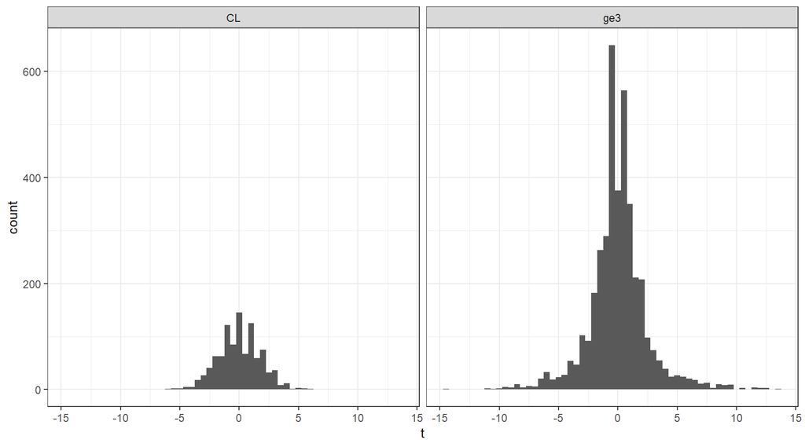

```r
# simulated sum cluster histogram
p = ggplot(sumt.df,aes(x = t))
p = p +geom_histogram(binwidth=0.5)
p = p + facet_wrap(~ HeadNoun)
p+theme_bw()
```

```r
# this code extracts out the maximum sum t for each simulation at each age
maxclusterdist = data.frame()
for (l in unique(sumt.df$HeadNoun)){
  for (s in unique(sumt.df$sim)) {
    # get all results for one simulation in one HeadNounuage
    onesim = subset(sumt.df,sim == s & HeadNoun == l)
    onesim$astruct = abs(onesim$t)
    # find max t-value
    maxrow = onesim[order(onesim$astruct,decreasing = T),]
    maxclusterdist = rbind(maxclusterdist,maxrow[1,])
  }
}
head(maxclusterdist)
```

```
##    HeadNoun cluster sim          t   astruct
## 1        CL      53   1 -1.6117687 1.6117687
## 6        CL      53   2 -1.2257058 1.2257058
## 11       CL      53   3 -1.9067490 1.9067490
## 16       CL      53   4 -0.5480236 0.5480236
## 21       CL      53   5 -0.2275692 0.2275692
## 26       CL      53   6  2.1272433 2.1272433
```

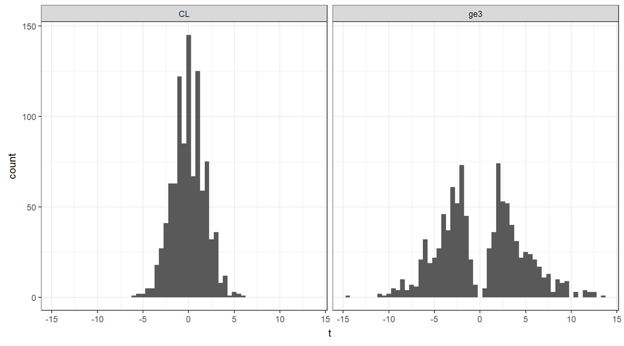

```r
# Shows the simulated distribution with maximum cluster t values
maxclusterdist2 = maxclusterdist[order(maxclusterdist$HeadNoun,maxclusterdist$t),]
p = ggplot(maxclusterdist,aes(x = t))
p = p +geom_histogram(binwidth=0.5)
p = p + facet_wrap(~ HeadNoun)
p+theme_bw()
```

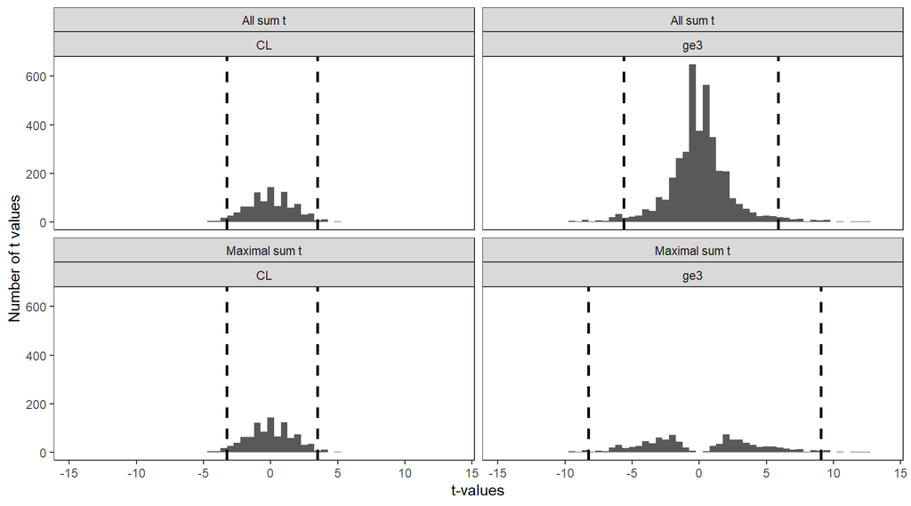

```r
maxclusterdist$type = "Maximal sum t"
sumt.df$astruct = abs(sumt.df$t)
sumt.df$type = "All sum t"
bothdist = rbind(sumt.df,maxclusterdist)
bothdist$c= 1
tvaldf = aggregate(c ~ type + HeadNoun, bothdist,sum)
tvaldf$upper= as.integer(tvaldf$c*0.975)
tvaldf$lower= as.integer(tvaldf$c*0.025)
sortbothdist = bothdist[order(bothdist$type,bothdist$HeadNoun,bothdist$t),]
tvaldf2 = tvaldf
for (e in tvaldf$HeadNoun){
  for (t in tvaldf$type){
    d = sortbothdist[sortbothdist$HeadNoun == e & sortbothdist$type==t,]
    u = tvaldf$upper[tvaldf$type == t & tvaldf$HeadNoun==e]
     l = tvaldf$lower[tvaldf$type == t & tvaldf$HeadNoun==e]
   tvaldf$bar[tvaldf$type == t & tvaldf$HeadNoun==e] = d$t[u]
    tvaldf2$bar[tvaldf2$type == t & tvaldf2$HeadNoun==e] = d$t[l]
 }
}
bothtvaldf = rbind(tvaldf2,tvaldf)

p = ggplot(bothdist,aes(x = t))
p = p +geom_histogram(binwidth=0.5)
#p = p +geom_vline(end,mapping=aes(xintercept=xint))
p = p + facet_wrap(~ type + HeadNoun, ncol=2)
p=p+theme_bw()+geom_vline(data=bothtvaldf,aes(xintercept=bar),linetype="dashed",size=1)
apaformat(p)+ylab("Number of t values")+xlab("t-values")
```

```r
ggsave("dist.png",width=6,height=4)
```

```r
# here we test all significant clusters against corresponding distribution
clmaxclusterdist = subset(maxclusterdist,HeadNoun == "CL")
gemaxclusterdist = subset(maxclusterdist,HeadNoun == "ge3")
# this identifies cluster tvalues that are greater than dist t-values
for (cl in unique(sumcluster$cnum)){
  bins = unique(means.df[means.df$cnum == cl,]$time)
  lan = sumcluster$HeadNoun[sumcluster$cnum == cl][1]

  tstr = abs(sumcluster$tstr[sumcluster$cnum==cl])
  # use appropriate distribution
   if (lan == "CL"){
     permtdist = clmaxclusterdist$astruct
   }else{
     permtdist = gemaxclusterdist$astruct
   }

  # permtdist is the dist t-values,
  # so p value is proportion of values greater than observed t-value.
  pstr = sum(abs(permtdist) > tstr, na.rm = TRUE)/length(permtdist)
  if (pstr < 0.025){
  print(paste("Cluster",cl,"Obs.sum t",round(tstr,3),"PropDist > observed p-value",pstr))
  }
  means.df$permtestp[means.df$time %in% bins & means.df$HeadNoun == lan] = pstr
}
```

```
## [1] "Cluster 53 Obs.sum t 5.995 PropDist > observed p-value 0.001"
## [1] "Cluster 124 Obs.sum t 43.045 PropDist > observed p-value 0"
```

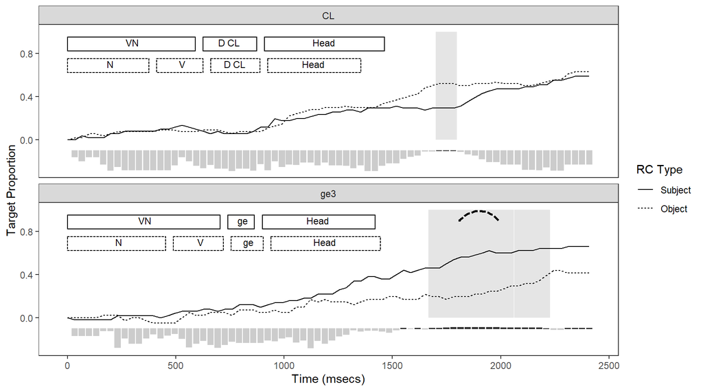

```r
# now we update our plot
p = ggplot(means.df , aes( x = time, y = target, linetype=SentenceType))
p = p + facet_wrap(~ HeadNoun, ncol=1)
# this pulls out the clusters which are significant by the permutation test
meansigStr = subset(means.df,permtestp < 0.025)
# color them grey
if (length(meansigStr$time) > 0){
  p = p + geom_rect(data=meansigStr,aes(xmin=time-wsize-4, xmax=time+wsize+4, ymin = pliney+0.1, ymax= 1.0),colour=NA,fill="grey90",show.legend=FALSE)
}
# same as before
p = p + geom_line()
p = p + scale_linetype_discrete(name="RC Type")
p = p + theme_bw()   # change background to white
p = p + ylab("Target Proportion")
p = p + xlab("Time (msecs)")
p = p + geom_rect(aes(xmin=time-wsize, xmax=time+wsize, ymin = pliney, ymax= pline, colour=plinecol,fill=plinecol),show.legend=FALSE)
p = p + geom_curve(data=meansigPost,aes(x=time+10, xend=time+winsize-10, y = 0.9, yend= 0.9),color="black",size=1, lineend = "square", curvature = -0.5, show.legend=FALSE)
p = p + geom_rect(data=onsetStim,aes(xmin=time,xmax = time2-33, ymin=ypos-0.13, ymax=ypos,linetype=SentenceType),fill=NA,colour="black", show.legend=FALSE)
p = p + geom_text(data=onsetStim,aes(x=(time+time2)/2, y=ypos-0.05, label=cat), hjust=0.7, size=3,show.legend=FALSE)
p = p +scale_colour_grey()
p = p +scale_fill_grey()
apaformat(p)
```

```r
ggsave("permCan.png",width=6,height=6)
```

The paper includes some figures to explain the permutation analysis. Here is the figure that shows three permutations of the original data.

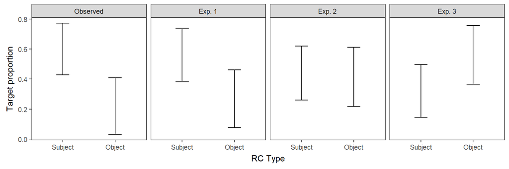

Here is the accuracy data analysis

```r
accdf = read.csv("accuracy data-19 for CL & 18 for GE - all correct trials.csv")
accdf$structure = factor(accdf$structure,labels=c("CL","ge3"))
accdf$extraction = factor(accdf$extraction ,labels=c("Subject","Object"),levels=c("subject","object"))

accdf$cCL = ifelse(accdf$structure == "CL",0.5,-0.5)
accdf$cobject = ifelse(accdf$extraction == "Object",0.5,-0.5)
accdf$participant=factor(accdf$participant)
accdf$item=factor(accdf$item)
xtabs( ~ structure + participant,accdf)
```

```
##          participant
## structure 1 2 3 4 5 6 7 8 9 10 11 12 13 14 15 16 17 18 19 20 21 22 23 24 25 26
##       CL  8 8 8 8 8 8 8 8 8  8  8  8  8  8  8  8  8  8  8  0  0  0  0  0  0  0
##       ge3 0 0 0 0 0 0 0 0 0  0  0  0  0  0  0  0  0  0  0  8  8  8  8  8  8  8
##          participant
## structure 27 28 29 30 31 32 33 34 35 36 37
##       CL   0  0  0  0  0  0  0  0  0  0  0
##       ge3  8  8  8  8  8  8  8  8  8  8  8
```

```r
xtabs( ~ extraction + participant,accdf)
```

```
##           participant
## extraction 1 2 3 4 5 6 7 8 9 10 11 12 13 14 15 16 17 18 19 20 21 22 23 24 25 26
##    Subject 4 4 4 4 4 4 4 4 4  4  4  4  4  4  4  4  4  4  4  4  4  4  4  4  4  4
##    Object  4 4 4 4 4 4 4 4 4  4  4  4  4  4  4  4  4  4  4  4  4  4  4  4  4  4
##           participant
## extraction 27 28 29 30 31 32 33 34 35 36 37
##    Subject  4  4  4  4  4  4  4  4  4  4  4
##    Object   4  4  4  4  4  4  4  4  4  4  4
```

```r
xtabs( ~ structure + item,accdf)
```

```
##          item
## structure O1 O2 O3 O4 O5 O6 O7 O8 S1 S2 S3 S4 S5 S6 S7 S8
##       CL  19 19 19 19  0  0  0  0 19 19 19 19  0  0  0  0
##       ge3  0  0  0  0 18 18 18 18  0  0  0  0 18 18 18 18
```

```r
xtabs( ~ extraction + item,accdf)
```

```
##           item
## extraction O1 O2 O3 O4 O5 O6 O7 O8 S1 S2 S3 S4 S5 S6 S7 S8
##    Subject  0  0  0  0  0  0  0  0 19 19 19 19 18 18 18 18
##    Object  19 19 19 19 18 18 18 18  0  0  0  0  0  0  0  0
```

```r
acc.glm = glmer(Correct ~ cobject*cCL + (1 | participant) + (1  | item),accdf,family="binomial")
```

```
## boundary (singular) fit: see ?isSingular
```

```r
print(summary(acc.glm))
```

```
## Generalized linear mixed model fit by maximum likelihood (Laplace
##   Approximation) [glmerMod]
##  Family: binomial  ( logit )
## Formula: Correct ~ cobject * cCL + (1 | participant) + (1 | item)
##    Data: accdf
##
##      AIC      BIC   logLik deviance df.resid
##    370.6    392.7   -179.3    358.6      290
##
## Scaled residuals:
##     Min      1Q  Median      3Q     Max
## -1.7413 -1.1451  0.5978  0.6195  0.8733
##
## Random effects:
##  Groups      Name        Variance  Std.Dev.
##  participant (Intercept) 7.934e-03 8.907e-02
##  item        (Intercept) 5.594e-10 2.365e-05
## Number of obs: 296, groups:  participant, 37; item, 16
##
## Fixed effects:
##             Estimate Std. Error z value Pr(>|z|)
## (Intercept)   0.8257     0.1320   6.256 3.94e-10 ***
## cobject      -0.4066     0.2564  -1.586    0.113
## cCL           0.4139     0.2581   1.604    0.109
## cobject:cCL   0.5411     0.5125   1.056    0.291
## ---
## Signif. codes:  0 '***' 0.001 '**' 0.01 '*' 0.05 '.' 0.1 ' ' 1
##
## Correlation of Fixed Effects:
##             (Intr) cobjct cCL
## cobject     -0.074
## cCL          0.048  0.028
## cobject:cCL  0.038  0.037 -0.062
## optimizer (Nelder_Mead) convergence code: 0 (OK)
## boundary (singular) fit: see ?isSingular
```

```r
accdf$pred = remef(acc.glm, ran = "all")
head(accdf)
```

```
##   item participant extraction Correct structure cCL cobject       pred
## 1   S1           1    Subject       1        CL 0.5    -0.5  1.8582111
## 2   S2           1    Subject       1        CL 0.5    -0.5  1.8582111
## 3   S3           1    Subject       0        CL 0.5    -0.5 -0.5657637
## 4   S4           1    Subject       1        CL 0.5    -0.5  1.8582111
## 5   O1           1     Object       1        CL 0.5     0.5  1.7679462
## 6   O2           1     Object       1        CL 0.5     0.5  1.7679462
```

```r
meandf = aggregate(Correct ~ extraction + structure, accdf, mean)
print(meandf)
```

```
##   extraction structure   Correct
## 1    Subject        CL 0.7500000
## 2     Object        CL 0.7236842
## 3    Subject       ge3 0.7222222
## 4     Object       ge3 0.5694444
```

```r
# compute sd from pred without random effects
meandf$sd = aggregate(pred ~ extraction + structure, accdf,sd)$pred
print(meandf)
```

```
##   extraction structure   Correct       sd
## 1    Subject        CL 0.7500000 1.055646
## 2     Object        CL 0.7236842 1.081280
## 3    Subject       ge3 0.7222222 1.085258
## 4     Object       ge3 0.5694444 1.174794
```

```r
# se is computed from sd divided by number of participants
meandf$se = meandf$sd/sqrt( nlevels(accdf$participant) )
meandf$upper = meandf$Correct + meandf$se
meandf$lower = meandf$Correct - meandf$se
print(meandf)
```

```
##   extraction structure   Correct       sd        se     upper     lower
## 1    Subject        CL 0.7500000 1.055646 0.1735471 0.9235471 0.5764529
## 2     Object        CL 0.7236842 1.081280 0.1777614 0.9014456 0.5459228
## 3    Subject       ge3 0.7222222 1.085258 0.1784154 0.9006376 0.5438069
## 4     Object       ge3 0.5694444 1.174794 0.1931349 0.7625793 0.3763095
```

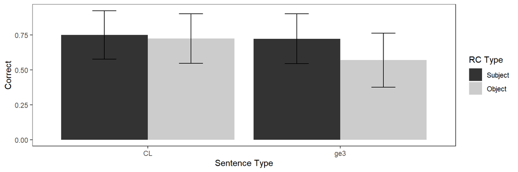

```r
p = ggplot(meandf, aes(x=structure,y=Correct, fill=extraction,ymin = lower, ymax=upper))
p = p +geom_bar(stat="identity",position="dodge")
p = p +scale_fill_grey(name="RC Type")
p = p + xlab("Sentence Type")
p = p + geom_errorbar(width=0.25, position=position_dodge(.9) )
apaformat(p)
```

```r
ggsave("accuracy.png",width=5,height=3)
```